# task3

Patrick Aquino

10/21/2020

# Task:

Is the relationship between a good or bad loan and the time between and account is opened and the loan is created? Is there a specific set of accounts that seem to be at higher or lower risk of defaulting?

# Procedure:

###1. Import dataset (accounts_analytical and transactions) ###2. Convert $acc_creation_date and $loan_date into date variables ###3. Create a new variable extracting the year the account was created and the year the loan was craeted ###4. Check each year with the highest default rate ###5. See the relationship of $loan_default with $owner_district

# Import

```r
acc <- read.csv('accounts_analytical.csv')
trans <- read.csv('transactions.csv')
```

# Coverting Data Variables

```r
library(lubridate)
acc$acct_creation_date <- ymd(acc$acct_creation_date)
acc$loan_date <- ymd(acc$loan_date)
```

# Creating Year variables for Account creation and Loan creation.

```r
acc$acc_year <- year(acc$acct_creation_date)
acc$loan_year <- year(acc$loan_date)
```

# Reducing Dimensions

```r
library(dplyr)
final <- acc %>%
  select(account_id, loan_year, acc_year, owner_district, loan_default)
```

# EDAish

```r
table(final$loan_default)
```

```
##
## FALSE  TRUE
##   606    76
```

```r
# 606 FALSE, 76 TRUE
# We want to examine TRUE
```

# Visualization for each Loan and Account creation year

```r
library(ggplot2)
library(tidyverse)
loan <- ggplot(final, aes(fill = loan_default, x = loan_year, y = account_id)) + geom_bar(position = 'fill', stat = 'identity')
account <- final %>%
  drop_na(loan_default) %>%
  ggplot(aes(x = acc_year, fill = loan_default, y = account_id)) +
  geom_bar(position = 'fill', stat = 'identity')
```

# Account Year

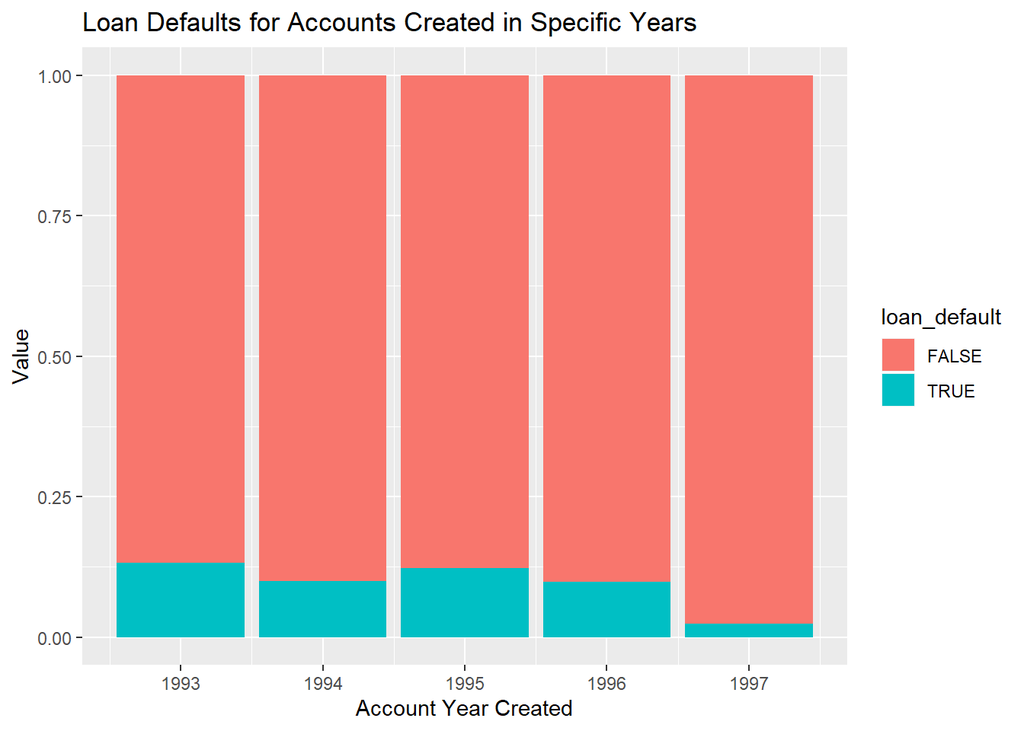

```r
account + labs(title = 'Loan Defaults for Accounts Created in Specific Years', x = 'Account Year Created', y = 'Value')
```

It seems that the years with the highest % defaults are in 1993 and 1995 for accounts that are created. Since 1995, the default rate has been dropping.

# Loan Year

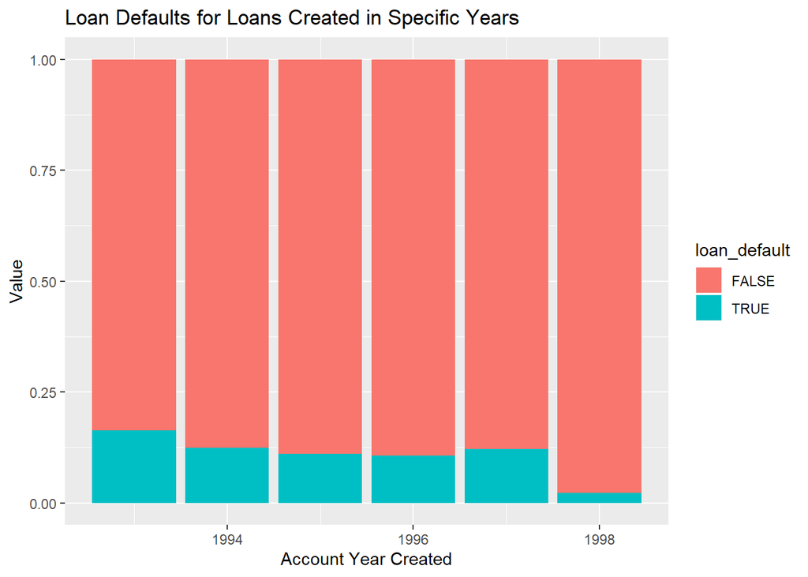

```r
loan + labs(title = 'Loan Defaults for Loans Created in Specific Years', x = 'Account Year Created', y = 'Value')
```

For loans that are created for a specific year, it seems that loans that are taken in 1998 seems to have a significant lower default rate. While the other years seem to have a similar default loan rate.

# Looking at the relationship between Loan Default and Districts

```r
dist <- final %>%
  drop_na(loan_default) %>%
  ggplot(aes(x = owner_district, fill = loan_default, y = account_id)) +
  geom_bar(position = 'fill', stat = 'identity')
```

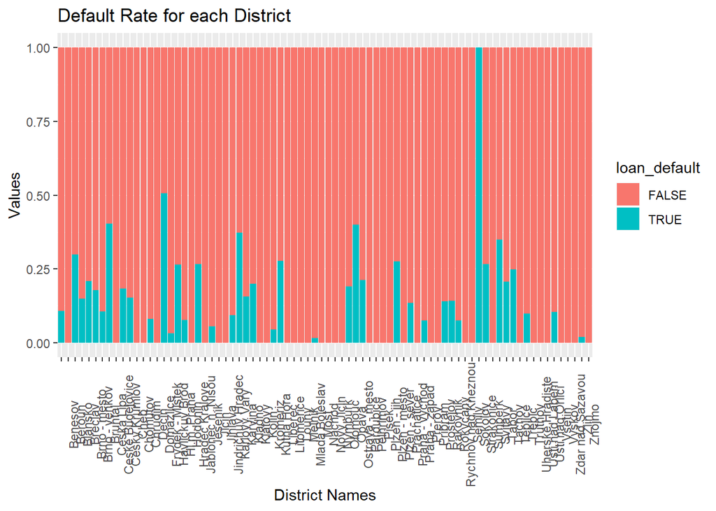

```r
dist + labs(title = 'Default Rate for each District', x= 'District Names', y = 'Values') + theme(axis.text.x = element_text(angle = 90))
```

It seems that some specific districts have higher default rates for accounts such as Semily, Decin, Jindichruv Hradek and Olomouc.